# 第10章 机器学习神器：XGBoost与Light-GBM算法

## 10.4 LightGBM算法原理

### 10.4.1 LightGBM算法的核心思想

- LightGBM算法是Boosting算法的新成员, 由微软公司开发

  与XGBoost算法一样是对GBDT算法的高效实现, 在原理上与GBDT算法和XGBoost算法类似, 都次啊用损失函数的负梯度作为当前决策树的残差近似值取拟合新的决策树
- 与传统的机器学习算法相比, LightGBM算法具有这些优势:

  训练效率更高;

  低内存使用;

  准确率更高;

  支持并行化学习;

  可以处理大规模数据

### 10.4.2 LightGBM算法的数学原理概述

- 官方说明文档地址: https://lightgbm.readthedocs.io
- LightGBM算法的数学原理涉及较多高等数学和线性代数的公式, 这里主要结合示意图讲解LightGBM算法数学原理的核心知识点
1. `基于leaf-wise的决策树生长策略`

   大部分决策树算法使用的生长策略是`level-wise`生长策略, 即同一层的叶子节点每次都一起分裂, 但实际上一些叶子节点的分裂增益较低, 这样分裂会增加不小的开销

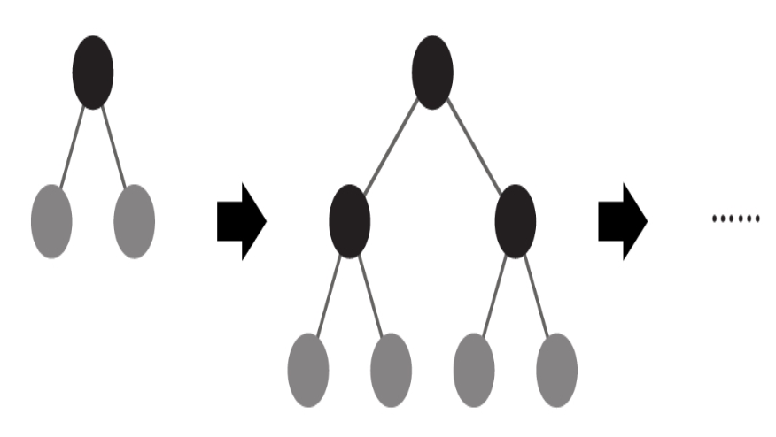

   LightGBM算法使用的则是`leaf-wise`生长策略, 每次在当前叶子节点找出`分裂增益最大的叶子节点`进行分裂, 而不是所有节点都进行分裂, 这样可以提高精度, 但是, leaf-wise策略在样本量较小时容易造成过拟合, LightGBM算法可以通过参数max_depth限制树的深度来放置过拟合

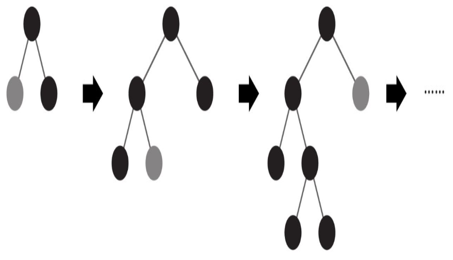

2. `直方图算法`

   直方图分为频数直方图和频率直方图, 横坐标为相关数据, 纵坐标为该数据出现的频数或频率

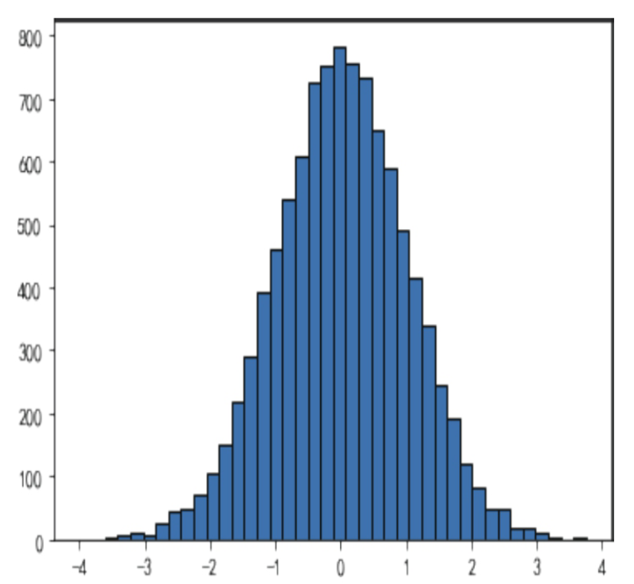

   直方图算法又称为histogram算法, 简单来说就是先对特征进行装箱处理, 将连续的浮点特征值离散化成 $k$ 个整数, 形成一个个箱体, 同时构造一个宽度为 $k$ 的直方图, 在遍历数据时, 以离散化后的值作为索引在直方图中累积统计量(因此这里是频数直方图), 遍历一次数据后, 直方图累积了需要的统计量, 再根据直方图的离散值遍历寻找最优分割点

   对于连续特征来说, 装箱处理就是特征工程中的离散化, 例如, $[0,10)$ 区间的值都赋值为0, 这样就可以把众多的数值划分到有限的分箱中, LightGBM算法中默认的分箱数(bins)为256

   对于分类特征来说, 则是将每一种取值放入一个分箱, 且当取值的个数大于最大分箱数时, 会忽略那些很少出现的分类值, 例如, 10000个客户的国际数据, 便可以按国家名称进行分箱, 如果超过最大分箱数, 那么很少出现的国家就会被忽略
3. `并行学习`(**不是很懂这部分**)

   LightGBM算法支持特征并行和数据并行两种学习方式

   传统的特征并行的主要思想是在并行化决策树中寻找最佳切分点, 在数据量大时难以加速, 同时需要对切分结果进行通信整合, 而LightGBM算法在本地保存全部数据, 这样就没有了机器间通信所需的开销

   此外, 传统的数据并行时构建本地直方图, 然后进行整合, 在全局直方图中寻找最佳切分点, LightGBM算法则使用分散规约, 将直方图合并的任务分给不同的机器, 降低通信和计算的开销, 并利用直方图做加速训练, 进一步减少开销

   除了上述原理, LightGBM算法还包含一些重要的算法思想, 如单边梯度采样GOSS(Gradient-based One-side Sampling)算法和互斥特征绑定EFB(Exclusive Feature Bundling)算法

   在GOSS算法中, 梯度更大的样本点在计算信息增益时会发挥更重要的作用, 当对样本进行下采样时保留这些梯度较大的样本点, 并随机去掉梯度小的样本点, EFB算法则将互斥特征绑在一起以减少特征维度

### 10.4.3 LightGBM算法的简单代码实现

```python
import warnings

warnings.filterwarnings('ignore')

# 忽略 LightGBM 的警告
warnings.filterwarnings("ignore", category=UserWarning, module="lightgbm")
```

```python
# LightGBM分类模型简单代码演示如下所示：
from lightgbm import LGBMClassifier

X = [[1, 2], [3, 4], [5, 6], [7, 8], [9, 10]]
y = [0, 0, 0, 1, 1]

# 设置 verbosity 为 -1，禁用所有日志输出
model = LGBMClassifier()
model.fit(X, y)

print(model.predict([[5, 5]]))
```

[output not shown]

[output cut: 159 more lines]

[output not shown]

```python
# LightGBM回归模型简单代码演示如下所示：
from lightgbm import LGBMRegressor
X = [[1, 2], [3, 4], [5, 6], [7, 8], [9, 10]]
y = [1, 2, 3, 4, 5]

model = LGBMRegressor()
model.fit(X, y)

print(model.predict([[5, 5]]))
```

[output not shown]

[output cut: 50 more lines]

[output not shown]